# OLS Regression

## Schedule

| Start | End | Duration | What | Who |
| --- | --- | --- | --- | --- |
| 1:00 PM | 1:45 PM | 0:45 | Review | Adam |
| 1:45 PM | 2:45 PM | 0:60 | OLS Regression | Brian |
| 2:45 PM | 3:15 PM | 0:30 | Break | You |
| 3:15 PM | 4:15 PM | 0:60 | GLMs | Brian |
| 4:15 PM | 5:00 PM | 0:45 | More tree-based methods | Adam |

# Linear regression

## Nomenclature

- target, response, prediction
- covariate, predictor, feature

## What are we assuming?

- Model is a pragmatic simulation of something complicated
- Response is a linear transform of an underlying random variable
- Reponse is an erroneous measurement of “truth”
- Response is the result of a stochastic process

## Fake it till you make it

```r
library(tidyverse)

num_sims <- 1e3
b_0 <- 5
b_1 <- -3
b_2 <- 2.5
regions <- c('north', 'south', 'east', 'west')

set.seed(1234)
tbl_ols <- tibble(
  x_1 = runif(num_sims, 0, 10)
  , x_2 = runif(num_sims, 30, 60)
  , x_3 = runif(num_sims, 200, 300)
  , x_4 = sample(regions, num_sims, replace = TRUE)
  , e = rnorm(num_sims, mean = 0, sd = 1)
)
```

## And some categorical data

```r
tbl_ols <- tbl_ols %>%
  mutate(
    y = b_0 + b_1 * x_1 + b_2 * x_2 + e
    , y = y + case_when(
      x_4 == 'north' ~ 10
      , x_4 == 'south' ~ -20
      , x_4 == 'east' ~ 50
      , x_4 == 'west' ~ -70
    )
  )
```

## Visual EDA

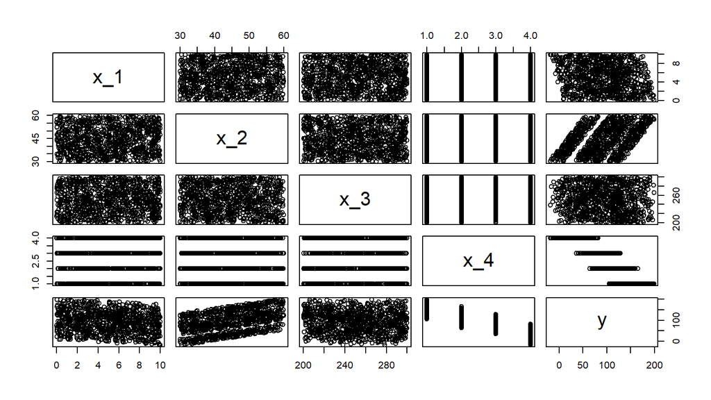

```r
tbl_ols %>%
  select(-e) %>%
  plot()
```

## Visual EDA two

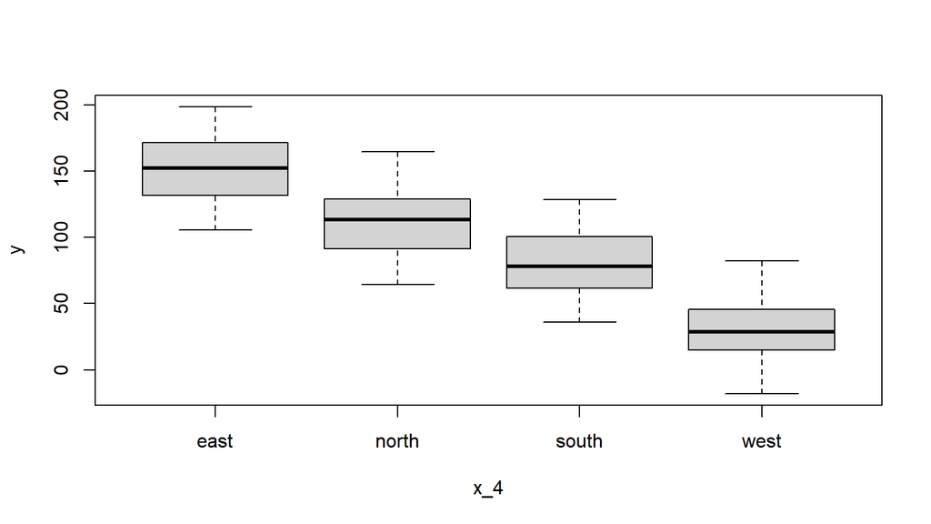

```r
tbl_ols %>%
  boxplot(y ~ x_4, data = .)
```

## Tabular EDA

```r
tbl_ols %>%
  select(x_1, x_2, x_3) %>%
  cor()
```

```
##             x_1         x_2          x_3
## x_1 1.000000000  0.02744029  0.007367743
## x_2 0.027440286  1.00000000 -0.042337439
## x_3 0.007367743 -0.04233744  1.000000000
```

## Fit a model

```r
fit_1 <- tbl_ols %>%
  lm(
    formula = y ~ x_1
  )
```

## Predict

```r
# tired
predict(fit_1) %>%
  head()
```

```
##         1         2         3         4         5         6
## 103.35920  89.36812  89.72642  89.33841  82.80399  88.87265
```

```r
# wired
tbl_ols <- tbl_ols %>%
  mutate(
    predict_one = predict(fit_1)
  )
```

## That was it

No, really. We’re done with building the model.

It’s just a call to `lm()`. No fussing with MLE, QR decomposition, matrix notation, or writing optimal code to arrive at the answer. The calibration has been done for you.

Any jerk can build a model.

# Formulas

## Formulas are models

We build a model through formulas.

What data do we think will predict our target?

`~` similar to its use in stats. $X \sim N(\mu, \sigma)$

I read `~` as “is modelled as”.

## Formulas

| Formula | What it means |
| --- | --- |
| y ~ x_1 | `y` deviates from an average by an amount scaled to `x_1` |
| y ~ 1 + x_1 | Same as the above |
| y ~ 1 | The sample average should be used to predict |
| y ~ 0 + x_1 | `y` is modeled as a constant scale of `x_1` |
| y ~ 1 + x_1 + x_2 | `y` deviates from average by amounts scaled to `x_1` and `x_2` |
| y ~ 1 + I(x_1 + x_2) | use `I()` for operations |
| y ~ x_1 + x2 + x_1:x_2 | Interactions: `x_1` and `x_2` matter more together |
| y ~ x_1 * x_2 | Give me all combinations of `x_1` and `x_2` |
| y ~ . | Use everything |

## Better by design

$$y_{i} = x_{ij} * \beta_i^T$$

The formula and linear algebra are all about constructing a design matrix. This is the data that will exist in your model.

What data? Let’s look. We can do this with the `model.matrix()` function.

## Univariate regression

```r
tbl_ols %>%
  model.matrix(y ~ x_1, data = .) %>%
  head()
```

```
##   (Intercept)      x_1
## 1           1 1.137034
## 2           1 6.222994
## 3           1 6.092747
## 4           1 6.233794
## 5           1 8.609154
## 6           1 6.403106
```

## Explicit intercept

```r
tbl_ols %>%
  model.matrix(y ~ 1 + x_1, data = .) %>%
  head()
```

```
##   (Intercept)      x_1
## 1           1 1.137034
## 2           1 6.222994
## 3           1 6.092747
## 4           1 6.233794
## 5           1 8.609154
## 6           1 6.403106
```

## Multivariate

```r
tbl_ols %>%
  model.matrix(y ~ x_1 + x_2, data = .) %>%
  head()
```

```
##   (Intercept)      x_1      x_2
## 1           1 1.137034 55.12902
## 2           1 6.222994 44.62399
## 3           1 6.092747 33.31011
## 4           1 6.233794 40.54089
## 5           1 8.609154 52.83189
## 6           1 6.403106 41.68995
```

## Interaction -> multiplication

```r
tbl_ols %>%
  model.matrix(y ~ x_1 + x_1:x_2, data = .) %>%
  head()
```

```
##   (Intercept)      x_1   x_1:x_2
## 1           1 1.137034  62.68357
## 2           1 6.222994 277.69481
## 3           1 6.092747 202.95008
## 4           1 6.233794 252.72358
## 5           1 8.609154 454.83788
## 6           1 6.403106 266.94514
```

Classic interaction: obesity and smoking as predictors of heart disease

## Star means everything

```r
tbl_ols %>%
  model.matrix(y ~ x_1*x_2, data = .) %>%
  head()
```

```
##   (Intercept)      x_1      x_2   x_1:x_2
## 1           1 1.137034 55.12902  62.68357
## 2           1 6.222994 44.62399 277.69481
## 3           1 6.092747 33.31011 202.95008
## 4           1 6.233794 40.54089 252.72358
## 5           1 8.609154 52.83189 454.83788
## 6           1 6.403106 41.68995 266.94514
```

## Everything!

```r
tbl_ols %>%
  model.matrix(y ~ 0 + x_1*x_2*x_3, data = .) %>%
  head()
```

```
##        x_1      x_2      x_3   x_1:x_2   x_1:x_3   x_2:x_3 x_1:x_2:x_3
## 1 1.137034 55.12902 211.4037  62.68357  240.3733 11654.480    13251.54
## 2 6.222994 44.62399 219.2208 277.69481 1364.2099  9782.507    60876.48
## 3 6.092747 33.31011 261.8471 202.95008 1595.3680  8722.155    53141.88
## 4 6.233794 40.54089 259.9059 252.72358 1620.2001 10536.818    65684.36
## 5 8.609154 52.83189 206.1884 454.83788 1775.1080 10893.325    93782.31
## 6 6.403106 41.68995 269.9254 266.94514 1728.3607 11253.173    72055.26
```

## Categories

```r
tbl_ols %>%
  model.matrix(y ~ x_4, data = .) %>%
  head()
```

```
##   (Intercept) x_4north x_4south x_4west
## 1           1        0        0       0
## 2           1        0        0       0
## 3           1        0        1       0
## 4           1        0        1       0
## 5           1        0        1       0
## 6           1        0        1       0
```

Also called “dummy variables”, or “one hot encoding”

## Categories and real

```r
tbl_ols %>%
  model.matrix(y ~ 0 + x_1 + x_4, data = .) %>%
  head()
```

```
##        x_1 x_4east x_4north x_4south x_4west
## 1 1.137034       1        0        0       0
## 2 6.222994       1        0        0       0
## 3 6.092747       0        0        1       0
## 4 6.233794       0        0        1       0
## 5 8.609154       0        0        1       0
## 6 6.403106       0        0        1       0
```

## Categories and real interactions

```r
tbl_ols %>%
  model.matrix(y ~ 0 + x_1:x_4, data = .) %>%
  head()
```

```
##   x_1:x_4east x_1:x_4north x_1:x_4south x_1:x_4west
## 1    1.137034            0     0.000000           0
## 2    6.222994            0     0.000000           0
## 3    0.000000            0     6.092747           0
## 4    0.000000            0     6.233794           0
## 5    0.000000            0     8.609154           0
## 6    0.000000            0     6.403106           0
```

```r
tbl_ols %>%
  model.matrix(y ~ 0 + x_1 + x_4, data = .) %>%
  head()
```

```
##        x_1 x_4east x_4north x_4south x_4west
## 1 1.137034       1        0        0       0
## 2 6.222994       1        0        0       0
## 3 6.092747       0        0        1       0
## 4 6.233794       0        0        1       0
## 5 8.609154       0        0        1       0
## 6 6.403106       0        0        1       0
```

```r
tbl_ols %>%
  model.matrix(y ~ 0 + x_1:x_4, data = .) %>%
  head()
```

```
##   x_1:x_4east x_1:x_4north x_1:x_4south x_1:x_4west
## 1    1.137034            0     0.000000           0
## 2    6.222994            0     0.000000           0
## 3    0.000000            0     6.092747           0
## 4    0.000000            0     6.233794           0
## 5    0.000000            0     8.609154           0
## 6    0.000000            0     6.403106           0
```

# Diagnose

## Summary

```r
summary(fit_1)
```

```
##
## Call:
## lm(formula = y ~ x_1, data = .)
##
## Residuals:
##    Min     1Q Median     3Q    Max
## -97.48 -39.17   2.23  37.59  97.03
##
## Coefficients:
##             Estimate Std. Error t value Pr(>|t|)
## (Intercept) 106.4871     3.1562  33.739  < 2e-16 ***
## x_1          -2.7509     0.5397  -5.097 4.12e-07 ***
## ---
## Signif. codes:  0 '***' 0.001 '**' 0.01 '*' 0.05 '.' 0.1 ' ' 1
##
## Residual standard error: 49.67 on 998 degrees of freedom
## Multiple R-squared:  0.02538,    Adjusted R-squared:  0.0244
## F-statistic: 25.98 on 1 and 998 DF,  p-value: 4.117e-07
```

## Extract data from the fit

| Element | What it shows |
| --- | --- |
| residuals | weighted residuals |
| coefficients | coefficients |
| sigma | square root |
| df | degrees of freedom |
| fstatistic | The F-stat |
| r.squared | r^2 |
| adj.r.squared | r^2 penalized for more parameters |
| cov.unscaled | covariance matrix |
| correlation | correlation matrix |

## Visualize the prediction

```r
tbl_fit_one <- tbl_ols %>%
  mutate(
    y_hat = predict(fit_1)
  )
```

## Visualize the prediction

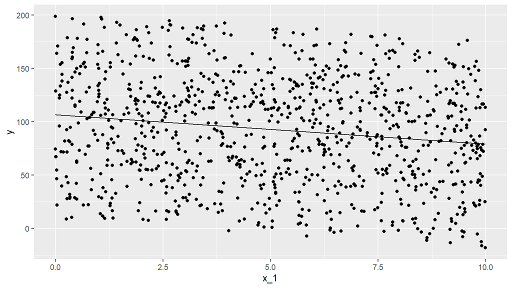

```r
tbl_fit_one %>%
  ggplot(aes(x_1)) +
  geom_point(aes(y = y)) +
  geom_line(aes(y = y_hat))
```

## Visualize the prediction

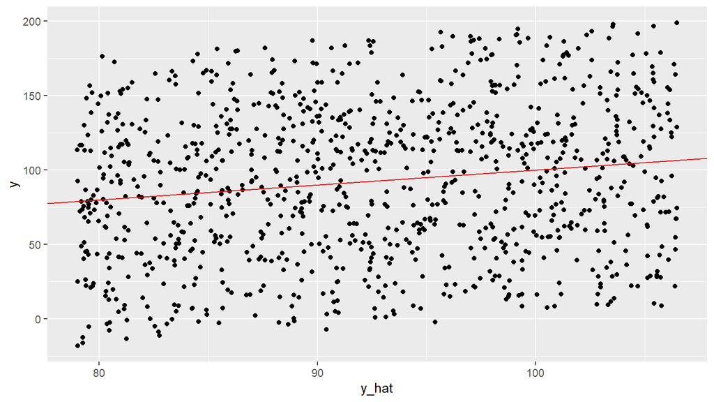

```r
tbl_fit_one %>%
  ggplot(aes(y_hat, y)) +
  geom_point() +
  geom_abline(slope = 1, intercept = 0, color = "red")
```

## Add residuals

```r
tbl_fit_one <- tbl_fit_one %>%
  mutate(
    residual = residuals(fit_1)
    , resid_standard = rstandard(fit_1)
  )
```

## Visualize the residuals

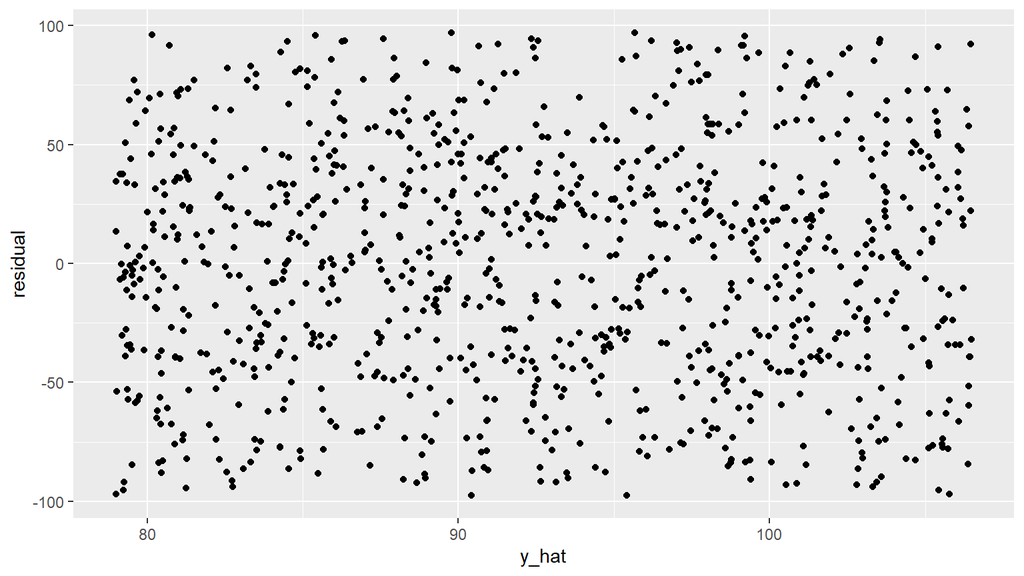

```r
tbl_fit_one %>%
  ggplot(aes(y_hat, residual)) +
  geom_point()
```

## Visualize the residuals

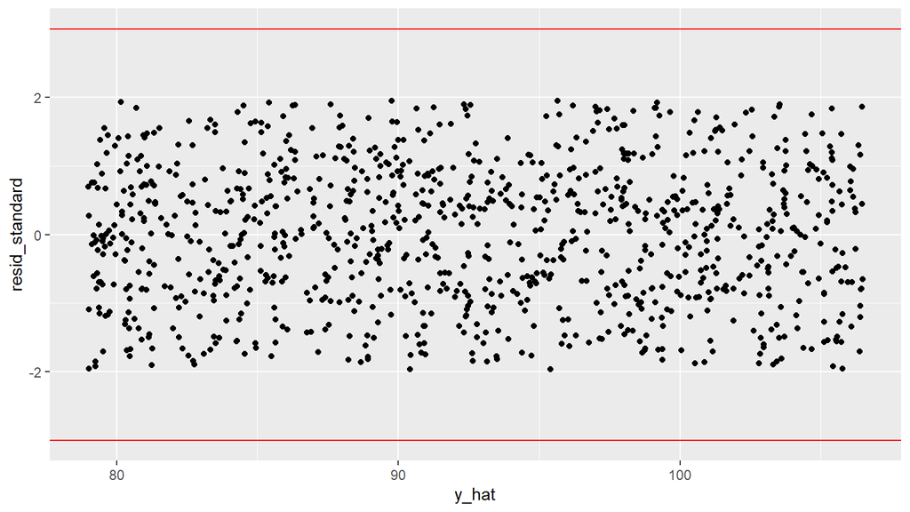

```r
tbl_fit_one %>%
  ggplot(aes(y_hat, resid_standard)) +
  geom_point() +
  geom_hline(yintercept = c(-3,3), color = "red")
```

## What are we looking for?

- Heteroskedasticity => We should change the weights applied to the observations
- Doesn’t look like “noise”
  - Serial correlation => Use a time series
  - Apply a transform (polynomial, trig, etc.)
- Extreme values => A normal distribution may not be appropriate

## Visualize residuals against other predictors

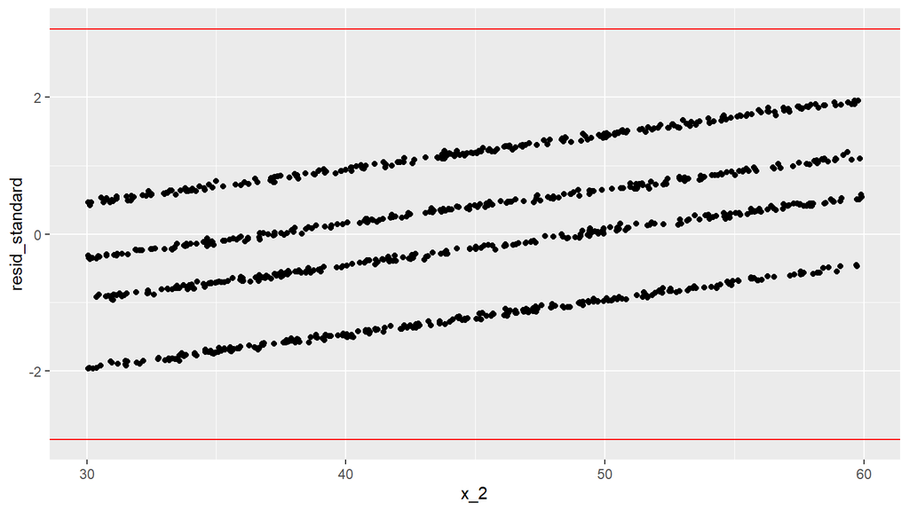

```r
tbl_fit_one %>%
  ggplot(aes(x_2, resid_standard)) +
  geom_point() +
  geom_hline(yintercept = c(-3,3), color = "red")
```

## Try more models

```r
fit_2 <- tbl_ols %>%
  lm(formula = y ~ x_1 + x_2)

fit_3 <- tbl_ols %>%
  lm(formula = y ~ x_1 + x_2 + x_3)

fit_4 <- tbl_ols %>%
  lm(formula = y ~ x_1 + x_3)
```

## Augment

```r
augment_model <- function(tbl_in, fit_in) {

  tbl_in %>%
    mutate(
      residual = residuals(fit_in)
      , resid_standard = rstandard(fit_in)
      , y_hat = predict(fit_in)
    )
}

tbl_fit_two <- tbl_ols %>% augment_model(fit_2)
tbl_fit_three <- tbl_ols %>% augment_model(fit_3)
tbl_fit_four <- tbl_ols %>% augment_model(fit_4)
```

## Visualize simultaneously

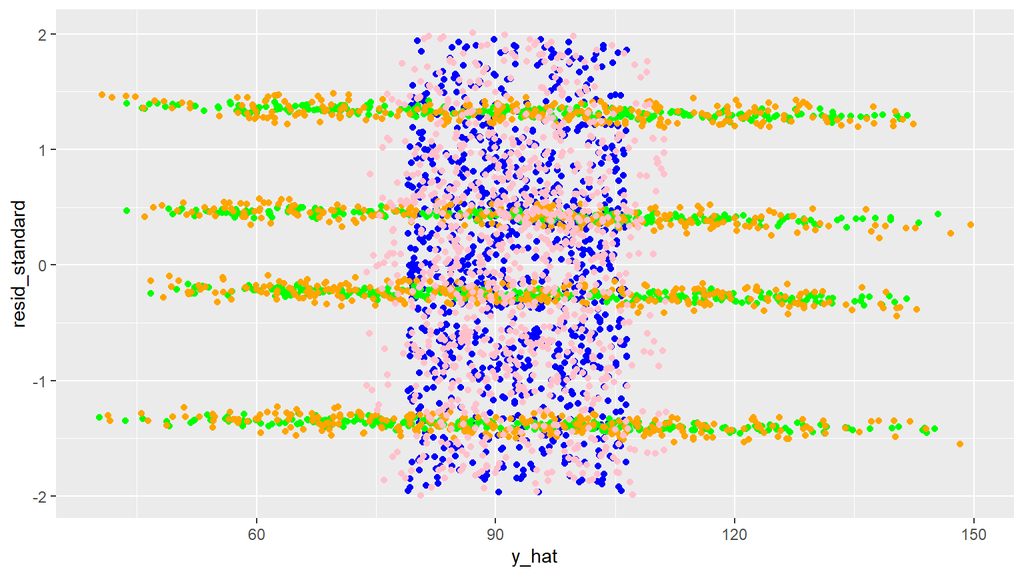

```r
tbl_fit_one %>% ggplot(aes(y_hat, resid_standard)) +
  geom_point(color = 'blue') +
  geom_point(color = 'green', data = tbl_fit_two) +
  geom_point(color = 'orange', data = tbl_fit_three) +
  geom_point(color = 'pink', data = tbl_fit_four)
```

## One more models

```r
fit_5 <- tbl_ols %>%
  select(-e) %>%
  lm(formula = y ~ .)

tbl_fit_five <- tbl_ols %>% augment_model(fit_5)
```

## Visualize one more

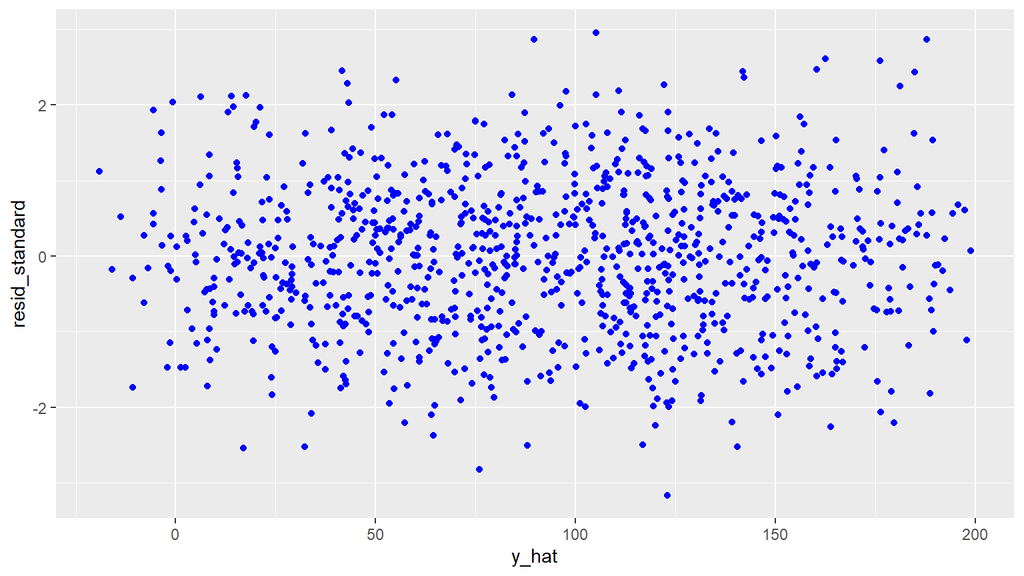

```r
tbl_fit_five %>% ggplot(aes(y_hat, resid_standard)) +
  geom_point(color = 'blue')
```

## Tabular look at multiple models

```r
library(broom)

fit_5 %>%
  tidy()
```

```
## # A tibble: 7 x 5
##   term           estimate std.error statistic p.value
##   <chr>             <dbl>     <dbl>     <dbl>   <dbl>
## 1 (Intercept)   54.9        0.343     160.      0
## 2 x_1           -3.01       0.0110   -273.      0
## 3 x_2            2.50       0.00380   658.      0
## 4 x_3            0.000420   0.00112     0.374   0.709
## 5 x_4north     -39.9        0.0930   -429.      0
## 6 x_4south     -70.0        0.0898   -780.      0
## 7 x_4west     -120.         0.0897  -1338.      0
```

## Sweeping up

```r
lst_fits <- list(
  one = fit_1
  , two = fit_2
  , three = fit_3
  , four = fit_4
  , five = fit_5
)

tbl_fits <- purrr::map_dfr(
  lst_fits
  , glance)

tbl_fits <- tbl_fits %>%
  mutate(model_name = names(lst_fits)) %>%
  select(model_name, everything())
```

## Lots of models

| model_name | r.squared | adj.r.squared | sigma | statistic | p.value |
| --- | --- | --- | --- | --- | --- |
| one | 0.0253753 | 0.0243987 | 49.672081 | 25.98390 | 4e-07 |
| two | 0.2235395 | 0.2219819 | 44.357904 | 143.51592 | 0e+00 |
| three | 0.2260986 | 0.2237676 | 44.306970 | 96.99523 | 0e+00 |
| four | 0.0302037 | 0.0282582 | 49.573731 | 15.52545 | 2e-07 |
| five | 0.9995964 | 0.9995940 | 1.013327 | 409913.24854 | 0e+00 |

| model_name | df | logLik | AIC | BIC | deviance | df.residual |
| --- | --- | --- | --- | --- | --- | --- |
| one | 2 | -5323.381 | 10652.761 | 10667.484 | 2462380.973 | 998 |
| two | 3 | -5209.727 | 10427.454 | 10447.085 | 1961720.812 | 997 |
| three | 4 | -5208.077 | 10426.153 | 10450.692 | 1955255.208 | 996 |
| four | 3 | -5320.897 | 10649.795 | 10669.426 | 2450182.172 | 997 |
| five | 7 | -1428.665 | 2873.331 | 2912.593 | 1019.644 | 993 |

# Wrapping up

## What we did

- Create a model based on some data
- Create a few more models based on data

## What we should do

- Visualize our data and our predictions
- Fit lots of models
- Diagnostics are good, but don’t fall in love with them